# Babylab data - exploration

To do

- correlate 24 month scores to 24 month neuro scores (see notes)
- confirm with david that the param1 can be ignored for now, as can be the dist

# 1 Intro

## 1.1 Context

One of the goals of sepages is to analyse the link between exposure to endocrine disruptors during pregnancy and the infant’s neurological development. One of the experiments to quantify neurologic development was to perform eye tracking experiments at Grenoble’s LPNC **BabyLab**. Sepages infants were subject to several tasks and were seen up to 3 times: at 5 months, 12 months, 24 months.

Here are the descriptive stats on the babylab dataset **DataFile_030220_anonym_id.csv**.

First we present the different tasks and scores. Then we briefly describe the population. Finally we decide on a subselection of scores for final analysis.

## 1.2 Eye tracking

Eye movement is measured by X-Y coordinates continuously. Eye movement consists of a sequence of **saccades** (movement) and **fixations** (non movements). Using the eye tracker several tasks are performed for which various scores were computed. Four tasks were performed for this study:

- **scene perception**
- **face perception and recognition**
- **saccades to target**
- **smooth pursuit**

### 1.2.1 Scene perception

An image is shown to the baby for five seconds each. The experiment is repeated six times.

We are interested in looking at what part of the image the infant looks at.

The scores available for this task are

1. The number of saccades during the task (`n_sacc_1`)
2. The values of a and b in the equation v = b*d^a (`param1_1` & `param2_1`)
3. The mean number of fixations over the six images (`n_fix_mean_1`)
4. The mean total time spent looking at the image (`look_t_mean_1`)
5. The mean duration of one fixation (`dur_fix_mean_1`)
6. A score to compute if the child looks at the same place of the image or not as the other children (`map_mean_1`)

### 1.2.2 Face perception and recognition

Two pictures of the same human face are simultaneously shown to the baby for 5 seconds. Then, one picture is replaced by a new one (the faces have different levels of attractiveness) and the two different pictures are shown to the baby for 5 seconds. The experiment is repeated four times.

We are interested in measuring the reaction to novelty: the baby should preferentially look at the new face.

But problem here: the duration of exposure to the different pictures is too long. **WHY???**

The scores available for this task are

1. The number of saccades during the task (`n_sacc_2`)
2. The values of a and b in the equation v = b*d^a (`param1_2` & `param2_2`)
3. The mean number of fixations over the six images (`n_fix_mean_2`)
4. The mean total time spent looking at the image (`look_t_mean_2`)
5. The mean duration of one fixation (`dur_fix_mean_2`)
6. The reaction to novel face over four tests (`novelty_2`) **need more info on formula**
7. Reaction time (`reaction_time_2`) **need more info on formula**
8. Percent time spent looking at eyes (`pct_eyes_2`)
9. Percent time spent looking at mouth (`pct_mouth_2`)

### 1.2.3 Saccades to target

The scores available for this task are

1. Reaction time (`reaction_time_3`) **need more info on formula**
2. Mean length of the first saccade to target (`dist_3`)

### 1.2.4 Smooth pursuit

The scores available for this task are

1. Reaction time (`reaction_time_4`) **need more info on formula**

# 2 Population description

## 2.1 Individuals

- N unique individuals = 188
- Sex:

|  | n | % | val% |
| --- | --- | --- | --- |
| F | 83 | 44.1 | 44.1 |
| M | 105 | 55.9 | 55.9 |

As a reminder in sepages: 251 boys (53%) and 218 girls (47%).

- Birth dates:

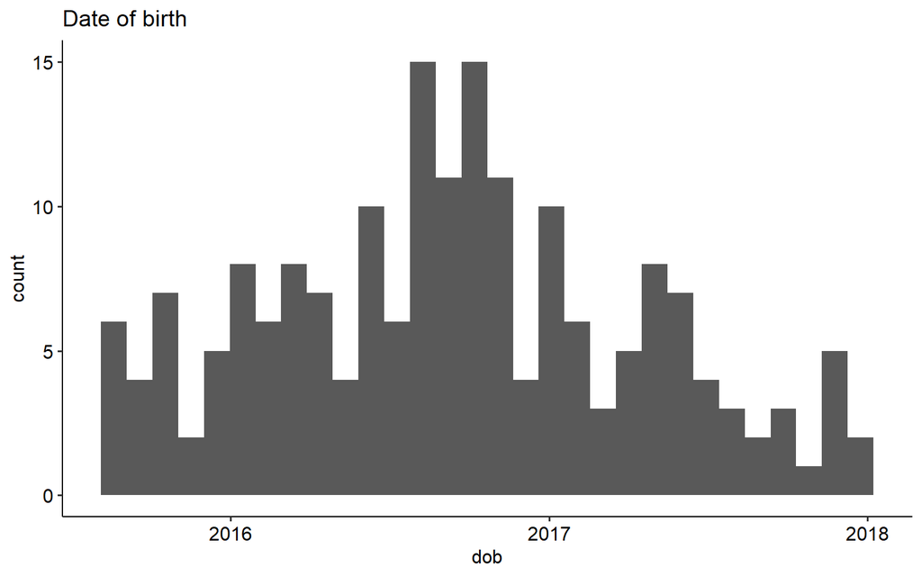

## 2.2 Experiments

- N experiments: 264

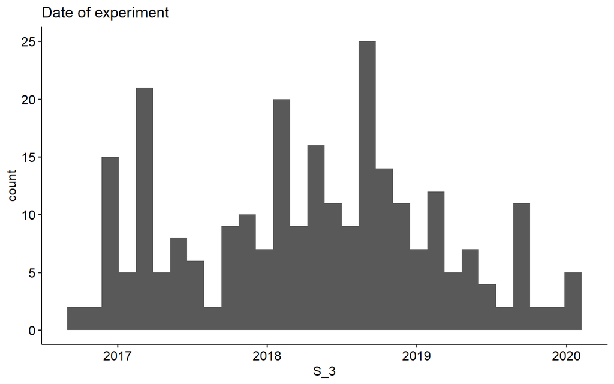

Task 2 missing for first 5 (not yet done) and when all signal was bad. (cf. notes meeting with DM 11/03/2020). Same for task 4. These tasks are more “difficult” so it’s harder to get valid signal.

## 2.3 Age at experiment

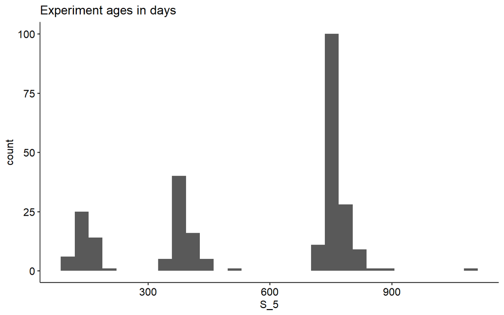

Older outlier:

```
## # A tibble: 1 x 4
##   date_birth date_exp   age_cat age_days
##   <date>     <date>       <dbl>    <dbl>
## 1 2016-12-07 2019-01-08      24     1097
```

True age in months = 1097 / 30.4 = 36…

**Error? Exclude?**

Three groups of age: 5 months, 12 months and 24 months with a majority of 24 months. Categorical age var:

|  | n | % | val% |
| --- | --- | --- | --- |
| 5 | 46 | 17.4 | 17.4 |
| 12 | 67 | 25.4 | 25.4 |
| 24 | 151 | 57.2 | 57.2 |

## 2.4 Repeated measures

Number of repeated data:

- 118 children with 1 experiment
- 64 children with 2 experiments
- 6 children with 3 experiments

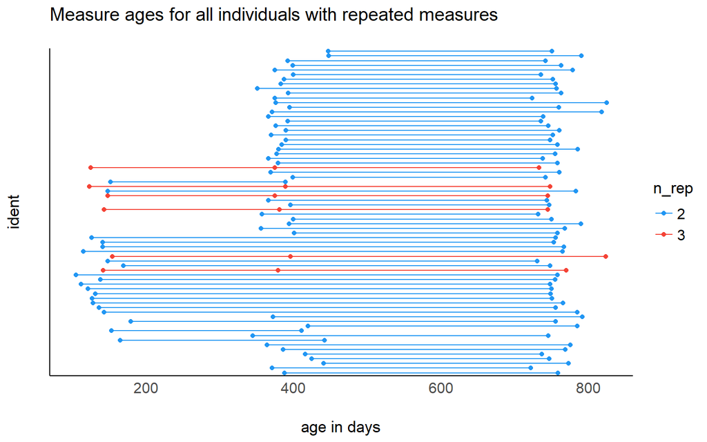

## 2.5 N with exposure

### 2.5.1 eye tracker 5 months

| period | n |
| --- | --- |
| exposure_T1 | 46/46 (100%) |
| exposure_T3 | 46/46 (100%) |
| exposure_M2 | 20/46 (43%) |
| exposure_Y1 | 14/46 (30%) |

### 2.5.2 eye tracker 12 months

| period | n |
| --- | --- |
| exposure_T1 | 67/67 (100%) |
| exposure_T3 | 67/67 (100%) |
| exposure_M2 | 14/67 (21%) |
| exposure_Y1 | 13/67 (19%) |

### 2.5.3 eye tracker 24 months

| period | n |
| --- | --- |
| exposure_T1 | 151/151 (100%) |
| exposure_T3 | 150/151 (99%) |
| exposure_M2 | 56/151 (37%) |
| exposure_Y1 | 40/151 (26%) |

# 3 Eye tracker scores

First we do some univariate statistics on the scores then we look at relations between them to see if we can/need to exclude some from further analysis.

## 3.1 Description

Data Frame Summary

**scores**  
**Dimensions**: 264 x 22  
**Duplicates**: 0

| **No** | **Variable** | **Label** | **Stats / Values** | **Freqs (% of Valid)** | **Graph** | **Missing** |
| --- | --- | --- | --- | --- | --- | --- |
| 1 | ident [character] | Unique child id | 1. 22692 2. 23250 3. 24921 4. 25043 5. 25130 6. 25509 7. 16606 8. 16958 9. 17154 10. 17465 [ 178 others ] | 3 ( 1.1% ) 3 ( 1.1% ) 3 ( 1.1% ) 3 ( 1.1% ) 3 ( 1.1% ) 3 ( 1.1% ) 2 ( 0.8% ) 2 ( 0.8% ) 2 ( 0.8% ) 2 ( 0.8% ) 238 ( 90.1% ) |  | 0 (0%) |
| 2 | S_4 [numeric] |  | Mean (sd) : 17.6 (7.7) min < med < max: 5 < 24 < 24 IQR (CV) : 12 (0.4) | 5 : 46 ( 17.4% ) 12 : 67 ( 25.4% ) 24 : 151 ( 57.2% ) |  | 0 (0%) |
| 3 | S_5 [numeric] | AgeInDays | Mean (sd) : 560.5 (249.6) min < med < max: 105 < 737.5 < 1097 IQR (CV) : 383.2 (0.4) | 149 distinct values |  | 0 (0%) |
| 4 | n_sacc_1 [numeric] | E1SaccNum (the number of saccades) | Mean (sd) : 82 (15.6) min < med < max: 38 < 81.5 < 170 IQR (CV) : 17.2 (0.2) | 62 distinct values |  | 0 (0%) |
| 5 | param1_1 [numeric] | E1param1 (the value of a in v = b*d^a, with v = max displacement per sample in pixels and d = distance in pixels) | Mean (sd) : 0.7 (0.1) min < med < max: 0.6 < 0.7 < 0.9 IQR (CV) : 0.1 (0.1) | 262 distinct values |  | 0 (0%) |
| 6 | param2_1 [numeric] | E1param2 (the value of b in v = b*d^a) | Mean (sd) : 0.7 (0.2) min < med < max: 0.2 < 0.7 < 1.4 IQR (CV) : 0.2 (0.3) | 264 distinct values |  | 0 (0%) |
| 7 | n_fix_mean_1 [numeric] | E1MeanFixNum (the mean number of fixation over 5 seconds of presentation for fixation quality == 1) | Mean (sd) : 9.1 (2.4) min < med < max: 2.5 < 9.3 < 14.5 IQR (CV) : 3.3 (0.3) | 73 distinct values |  | 0 (0%) |
| 8 | dur_fix_mean_1 [numeric] | E1MeanFixDur (the mean duration of one fixation for fixation quality == 1) | Mean (sd) : 370 (60.1) min < med < max: 272 < 358 < 697 IQR (CV) : 77 (0.2) | 151 distinct values |  | 0 (0%) |
| 9 | map_mean_1 [numeric] | E1MeanMapFix (the mean of density map values at fixations points for fixation quality == 1 \| 2) | Mean (sd) : 0.1 (0) min < med < max: 0 < 0.1 < 0.1 IQR (CV) : 0 (0.2) | 264 distinct values |  | 0 (0%) |
| 10 | n_sacc_2 [numeric] | E2SaccNum | Mean (sd) : 97.8 (15.9) min < med < max: 46 < 99 < 148 IQR (CV) : 20.5 (0.2) | 69 distinct values |  | 9 (3.41%) |
| 11 | param1_2 [numeric] | E2param1 | Mean (sd) : 0.7 (0.1) min < med < max: 0.5 < 0.7 < 0.9 IQR (CV) : 0.1 (0.1) | 254 distinct values |  | 9 (3.41%) |
| 12 | param2_2 [numeric] | E2param2 | Mean (sd) : 0.8 (0.2) min < med < max: 0.3 < 0.8 < 1.6 IQR (CV) : 0.3 (0.3) | 254 distinct values |  | 9 (3.41%) |
| 13 | n_fix_mean_2 [numeric] | E2MeanFixNum | Mean (sd) : 8.3 (2.3) min < med < max: 2 < 8.2 < 15.8 IQR (CV) : 2.9 (0.3) | 72 distinct values |  | 9 (3.41%) |
| 14 | dur_fix_mean_2 [numeric] | E2MeanFixDur | Mean (sd) : 382.8 (66.8) min < med < max: 222 < 372 < 607 IQR (CV) : 80.5 (0.2) | 149 distinct values |  | 9 (3.41%) |
| 15 | map_mean_2 [numeric] | E2MeanMapFix | Mean (sd) : 0.1 (0) min < med < max: 0 < 0.1 < 0.1 IQR (CV) : 0 (0.2) | 254 distinct values |  | 9 (3.41%) |
| 16 | novelty_2 [numeric] | E2Nov (the reaction to novel face over the four test [New-Old]./[New+Old]) | Mean (sd) : 0.1 (0.2) min < med < max: -0.4 < 0.1 < 0.6 IQR (CV) : 0.2 (1.8) | 255 distinct values |  | 9 (3.41%) |
| 17 | reaction_time_2 [numeric] | E2RT (reaction time at face onset) | Mean (sd) : 420.2 (84.8) min < med < max: 248 < 414.3 < 844 IQR (CV) : 104.8 (0.2) | 237 distinct values |  | 9 (3.41%) |
| 18 | pct_eyes_2 [numeric] | E2Eyes (percent time on eyes) | Mean (sd) : 0.7 (0.2) min < med < max: 0.1 < 0.7 < 1 IQR (CV) : 0.2 (0.3) | 255 distinct values |  | 9 (3.41%) |
| 19 | pct_mouth_2 [numeric] | E2Mouth (percent time on mouth) | Mean (sd) : 0.1 (0.2) min < med < max: 0 < 0.1 < 0.8 IQR (CV) : 0.2 (1.1) | 235 distinct values |  | 9 (3.41%) |
| 20 | reaction_time_3 [numeric] | E3RT | Mean (sd) : 288.2 (58.4) min < med < max: 182 < 281.5 < 484 IQR (CV) : 69.5 (0.2) | 75 distinct values |  | 166 (62.88%) |
| 21 | dist_3 [numeric] | E3Dist (mean length of the first saccade to target) | Mean (sd) : 187 (28) min < med < max: 128.3 < 185.4 < 345 IQR (CV) : 28.1 (0.1) | 260 distinct values |  | 4 (1.52%) |
| 22 | reaction_time_4 [numeric] | E4RT | Mean (sd) : 330 (88.3) min < med < max: 96 < 313 < 750 IQR (CV) : 89 (0.3) | 171 distinct values |  | 16 (6.06%) |

Also 16 missing task 4, will exclude for now.

## 3.2 Score vs age

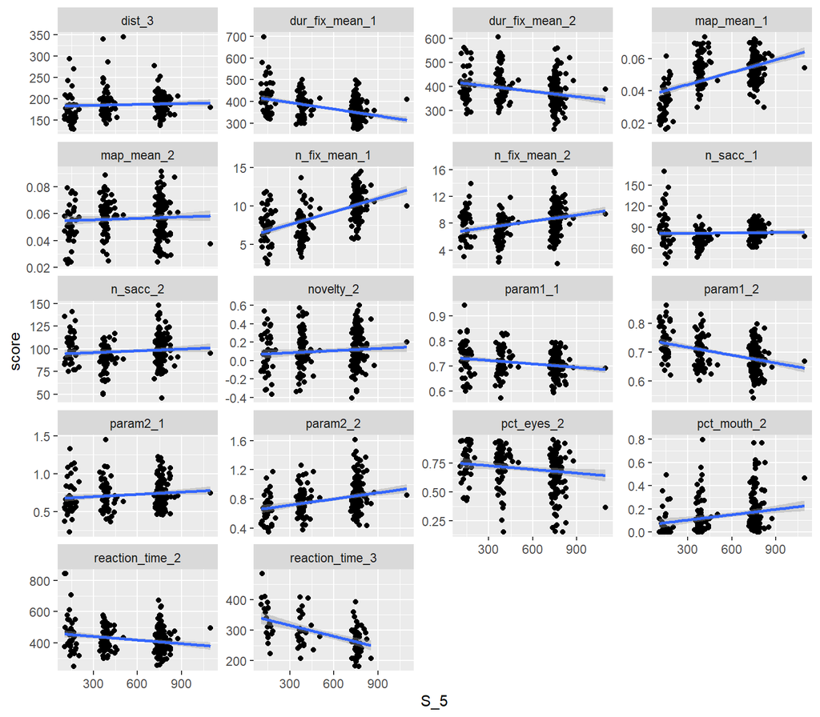

- There seems to be a strong age effect hEnce I stratify the following descriptive analyses by group age

## 3.3 Correlation between scores

Here we look at how the scores are correlated. We will focus on scores that are supposed to measure the same trait accross different tasks (eg reaction time at task 2 and 3) and scores that are mathematically linked (eg number of saccades and number of fixations).

### 3.3.1 Absolute correlations between all scores

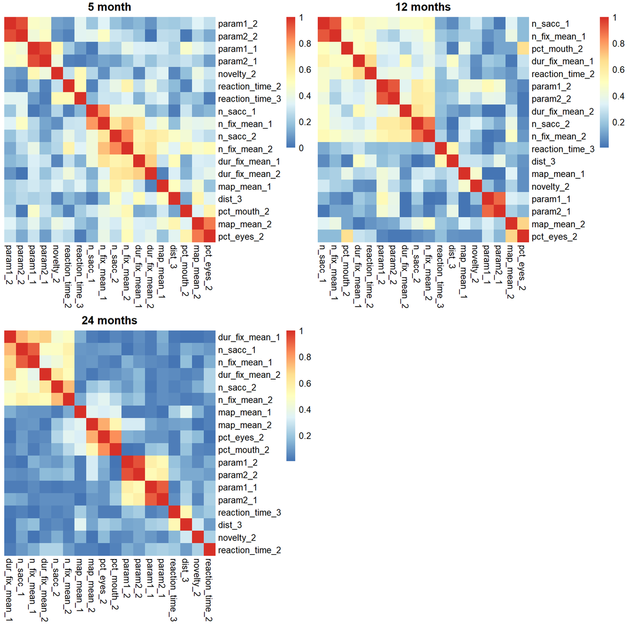

- all scores that measure saccade/fixations are grouped
- the saccade equation parameters param1 and param2 highly correlated
- the task 2 qualitative indicators pct_eyes, pct_mouth and map_mean correlated
- correlations increase with age

David (cf notes meeting 11/03/2020)

> - param1 donne une estimation de la « vitesse de base » du sujet
> - param2 = facteur de mise a l’échelle en fonction de l’amplitude
> - pas forcément de choix évident, on va commencer avec le param1

=> drop `param2_1` & `param2_2`

> Entre n fix, n sacc et dur moyenne fix pour qual == 1 (qui sont les 3 liées) : Garder absolumùent la durée moyenne de fixation car normalement, représente l’état attentionnel de l’enfant (tps mis a traiter l’info regardée). Un comportement exploratoire va se traduire par un gd nb de fiwx, plus courtes

=> drop `n_sacc_1`, `n_sacc_2`, `n_fix_mean_1` & `n_fix_mean_2`

> Pct eyes et mouth : choisir les yeux parceque c’est la cible privilégéies de l’attention visuelle des visages statiques (pas pareil si c’est un visage parlant). Yeux utilisés sur les études du trouble du spectre autistique par ex. Indicateur a prioi plus sensible de la cignition sociale de l’enfanrt. Attention car trop peu regarder ou trop regarder les yeux peut etre le signe d’un comporteùment atypique (peut etre regarder la distance a la moyenne).

> Pour la taxche 2 on va enlever le mean map car on a déjà une mesure de l’endroit de la fixation par les yeux mais qui est plus indicatrice de de la typicité du comprtement.

=> drop `pct_mouth_2` & `map_mean_2`

Remaining scores for analysis:

- `dur_fix_mean_1`
- `param1_1`
- `map_mean_1`
- `pct_eyes_2`
- `dur_fix_mean_2`
- `param1_2`
- `reaction_time_2`
- `novelty_2`
- `dist_3`
- `reaction_time_3`
- `reaction_time_4`

### 3.3.2 Correlation between tasks

Correlations on same scores/different tasks:

| rowname | score | cor5 | cor12 | cor24 |
| --- | --- | --- | --- | --- |
| n_fix_mean_1 | n_fix_mean_2 | 0.72 | 0.47 | 0.54 |
| dur_fix_mean_1 | dur_fix_mean_2 | 0.70 | 0.52 | 0.69 |
| reaction_time_2 | reaction_time_3 | 0.53 | 0.18 | 0.21 |
| param2_1 | param2_2 | 0.49 | 0.38 | 0.58 |
| param1_1 | param1_2 | 0.47 | 0.53 | 0.57 |
| map_mean_1 | map_mean_2 | 0.44 | 0.34 | 0.36 |
| n_sacc_1 | n_sacc_2 | 0.43 | 0.47 | 0.49 |

## 3.4 Correlation with CBCL scores

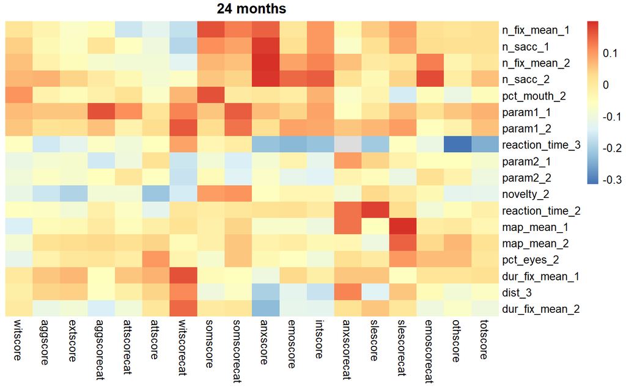

Max correlation = 0.2

Min correlation = -0.32

Top 5 correlations:

| babylab_task | cbcl_task | cor |
| --- | --- | --- |
| n_fix_mean_2 | anxscore | 0.20 |
| map_mean_1 | slescorecat | 0.20 |
| n_sacc_2 | anxscore | 0.19 |
| n_sacc_1 | anxscore | 0.19 |
| reaction_time_2 | slescore | 0.18 |

Bottom 5 correlations:

| babylab_task | cbcl_task | cor |
| --- | --- | --- |
| reaction_time_3 | anxscore | -0.22 |
| dur_fix_mean_2 | anxscore | -0.23 |
| reaction_time_3 | emoscore | -0.24 |
| reaction_time_3 | totscore | -0.24 |
| reaction_time_3 | othscore | -0.32 |

## 3.5 Conclusions

- Scores are linked with age
- Some variables are highly correlated hence the final selection of variables:
- `dur_fix_mean_1`
- `param1_1`
- `map_mean_1`
- `pct_eyes_2`
- `dur_fix_mean_2`
- `param1_2`
- `reaction_time_2`
- `novelty_2`
- `dist_3`
- `reaction_time_3`
- `reaction_time_4`
- These Correlations/groupings get clearer with age

A further selection is applied by **excluding** less interpretable vars `param1_1`, `param1_2` and `dist_3`.

And indicators will be grouped as follow as they are correlated and measure the same feature:

- **Group 1**: `dur_fix_mean_1`, `dur_fix_mean_2`
- **Group 2**: `map_mean_1`, `pct_eyes_2`
- **Group 3**: `reaction_time_2`, `reaction_time_3`, `reaction_time_4`
- **Group 4**: `novelty_2`

# 4 Annex: Repeated measures

## 4.1 Correlations

Correlation for each score between each period (5 months, 12 months and 24 months):

| task | cor_5_12 | n_1 | cor_12_24 | n_2 | cor_5_24 | n_3 |
| --- | --- | --- | --- | --- | --- | --- |
| dur_fix_mean_1 | 0.64 | 9 | 0.69 | 50 | 0.08 | 23 |
| pct_mouth_2 | -0.30 | 6 | 0.60 | 48 | 0.38 | 20 |
| pct_eyes_2 | 0.50 | 6 | 0.56 | 48 | 0.08 | 20 |
| dur_fix_mean_2 | 0.63 | 6 | 0.49 | 48 | 0.60 | 20 |
| n_sacc_1 | 0.61 | 9 | 0.46 | 50 | 0.07 | 23 |
| n_sacc_2 | 0.57 | 6 | 0.41 | 48 | 0.24 | 20 |
| param1_1 | 0.10 | 9 | 0.39 | 50 | 0.33 | 23 |
| n_fix_mean_2 | 0.74 | 6 | 0.37 | 48 | 0.33 | 20 |
| map_mean_2 | 0.95 | 6 | 0.35 | 48 | 0.12 | 20 |
| param2_1 | 0.08 | 9 | 0.30 | 50 | 0.18 | 23 |
| map_mean_1 | -0.18 | 9 | 0.27 | 50 | 0.21 | 23 |
| n_fix_mean_1 | 0.55 | 9 | 0.26 | 50 | 0.40 | 23 |
| param2_2 | 0.32 | 6 | 0.25 | 48 | 0.21 | 20 |
| reaction_time_2 | 0.37 | 6 | 0.25 | 48 | 0.15 | 20 |
| novelty_2 | -0.03 | 6 | 0.24 | 48 | 0.11 | 20 |
| param1_2 | 0.07 | 6 | 0.21 | 48 | 0.17 | 20 |
| dist_3 | 0.28 | 8 | 0.14 | 48 | 0.07 | 21 |

## 4.2 Visualisation

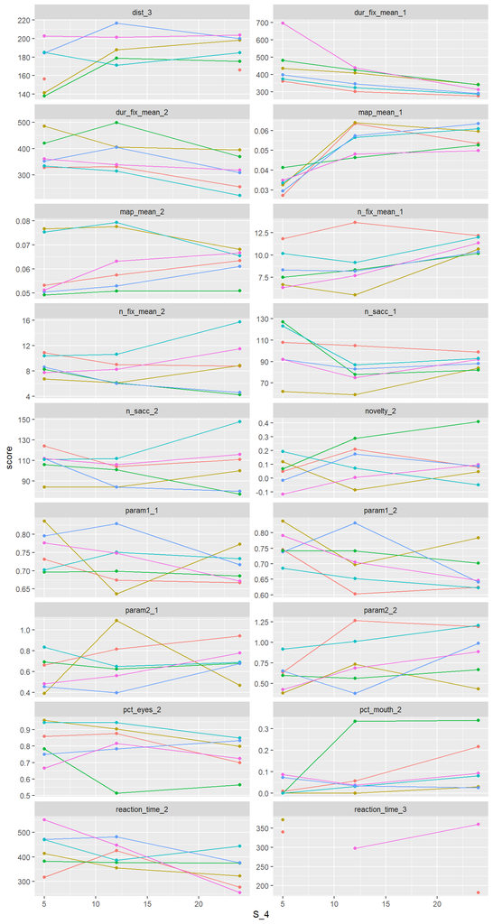

## 4.3 Conclusions

Not sure yet what we can do with the repeated measures.